# netflix_eda

## Netflix EDA and Visualization

```python
#Importing necessary packages
import pandas as pd
import numpy as np
import matplotlib.pyplot as plt
import seaborn as sns
import regex as re
import warnings
warnings.filterwarnings('ignore')
```

1. Defining Problem Statement and Analysing basic metrics (10 Points)
   - We are trying to observe patterns in the Netflix data which can help us to take decision with respect to future plan
   - We are seeing patterns between type of content in various countries, top genres and their rating etc.
- We are ultimately getting insights to make decisions about plans of content in various regions to improve the watching experience of the customers
1. Observations on the shape of data, data types of all the attributes, conversion of categorical attributes to 'category' (If required), missing value detection, statistical summary (10 Points)

```python
#Load Data
df=pd.read_csv("netflix.csv")
df.head(3)
```

|  | show_id | type | title | director | cast | country | date_added | release_year | rating | duration | listed_in | description |
| --- | --- | --- | --- | --- | --- | --- | --- | --- | --- | --- | --- | --- |
| 0 | s1 | Movie | Dick Johnson Is Dead | Kirsten Johnson | NaN | United States | September 25, 2021 | 2020 | PG-13 | 90 min | Documentaries | As her father nears the end of his life, filmm... |
| 1 | s2 | TV Show | Blood & Water | NaN | Ama Qamata, Khosi Ngema, Gail Mabalane, Thaban... | South Africa | September 24, 2021 | 2021 | TV-MA | 2 Seasons | International TV Shows, TV Dramas, TV Mysteries | After crossing paths at a party, a Cape Town t... |
| 2 | s3 | TV Show | Ganglands | Julien Leclercq | Sami Bouajila, Tracy Gotoas, Samuel Jouy, Nabi... | NaN | September 24, 2021 | 2021 | TV-MA | 1 Season | Crime TV Shows, International TV Shows, TV Act... | To protect his family from a powerful drug lor... |

```python
#Shape of data
print(f"The dataset has {df.shape[0]} rows and {df.shape[1]} columns",'\n','-'*50)
print(f"Number of duplicate rows in data = {df.duplicated().sum()}","\n",'-'*50)
#Data types of all attributes
print(df.info())
```

```
The dataset has 8807 rows and 12 columns
 --------------------------------------------------
Number of duplicate rows in data = 0
 --------------------------------------------------
<class 'pandas.core.frame.DataFrame'>
RangeIndex: 8807 entries, 0 to 8806
Data columns (total 12 columns):
 #   Column        Non-Null Count  Dtype
---  ------        --------------  -----
 0   show_id       8807 non-null   object
 1   type          8807 non-null   object
 2   title         8807 non-null   object
 3   director      6173 non-null   object
 4   cast          7982 non-null   object
 5   country       7976 non-null   object
 6   date_added    8797 non-null   object
 7   release_year  8807 non-null   int64
 8   rating        8803 non-null   object
 9   duration      8804 non-null   object
 10  listed_in     8807 non-null   object
 11  description   8807 non-null   object
dtypes: int64(1), object(11)
memory usage: 825.8+ KB
None
```

```python
df.dtypes.value_counts()
```

```
object    11
int64      1
dtype: int64
```

```python
#Necessary initial column transformations/additions
df['date_added']=pd.to_datetime(df['date_added'])
df['year_added']=df['date_added'].dt.year
df['month_added']=df['date_added'].dt.month
df['tot_seasons']=df['duration'].str.extract(r'(\d+) Season[s]?', expand=False).astype(float)
df['duration']=df['duration'].str.extract(r'(\d+) min', expand=False).astype(float)
df.rename(columns={'listed_in':'genre'},inplace=True)
```

```python
#Statistical Summary for numeric and date columns
df.describe(datetime_is_numeric=True)
```

|  | date_added | release_year | duration | year_added | month_added | tot_seasons |
| --- | --- | --- | --- | --- | --- | --- |
| count | 8797 | 8807.000000 | 6128.000000 | 8797.000000 | 8797.000000 | 2676.000000 |
| mean | 2019-05-17 05:59:08.436967168 | 2014.180198 | 99.577187 | 2018.871888 | 6.654996 | 1.764948 |
| min | 2008-01-01 00:00:00 | 1925.000000 | 3.000000 | 2008.000000 | 1.000000 | 1.000000 |
| 25% | 2018-04-06 00:00:00 | 2013.000000 | 87.000000 | 2018.000000 | 4.000000 | 1.000000 |
| 50% | 2019-07-02 00:00:00 | 2017.000000 | 98.000000 | 2019.000000 | 7.000000 | 1.000000 |
| 75% | 2020-08-19 00:00:00 | 2019.000000 | 114.000000 | 2020.000000 | 10.000000 | 2.000000 |
| max | 2021-09-25 00:00:00 | 2021.000000 | 312.000000 | 2021.000000 | 12.000000 | 17.000000 |
| std | NaN | 8.819312 | 28.290593 | 1.574243 | 3.436554 | 1.582752 |

```python
#Statistical Summary for object data type columns
df.describe(include='object')
```

|  | show_id | type | title | director | cast | country | rating | genre | description |
| --- | --- | --- | --- | --- | --- | --- | --- | --- | --- |
| count | 8807 | 8807 | 8807 | 6173 | 7982 | 7976 | 8803 | 8807 | 8807 |
| unique | 8807 | 2 | 8807 | 4528 | 7692 | 748 | 17 | 514 | 8775 |
| top | s1 | Movie | Dick Johnson Is Dead | Rajiv Chilaka | David Attenborough | United States | TV-MA | Dramas, International Movies | Paranormal activity at a lush, abandoned prope... |
| freq | 1 | 6131 | 1 | 19 | 19 | 2818 | 3207 | 362 | 4 |

The shape of data is (8807,12).Range of attributes are mentioned below

- Date_added is [2008-01-01,2021-09-25]
- Release year is [1925,2021]
- Duration is [3min,312min]
- Tot_season is [1,17]

```python
#Missing value estimation
print(round(df.isna().mean()*100,2)) , print('-'*70),print(df.isna().sum())
```

```
show_id          0.00
type             0.00
title            0.00
director        29.91
cast             9.37
country          9.44
date_added       0.11
release_year     0.00
rating           0.05
duration        30.42
genre            0.00
description      0.00
year_added       0.11
month_added      0.11
tot_seasons     69.62
dtype: float64
----------------------------------------------------------------------
show_id            0
type               0
title              0
director        2634
cast             825
country          831
date_added        10
release_year       0
rating             4
duration        2679
genre              0
description        0
year_added        10
month_added       10
tot_seasons     6131
dtype: int64
```

```
(None, None, None)
```

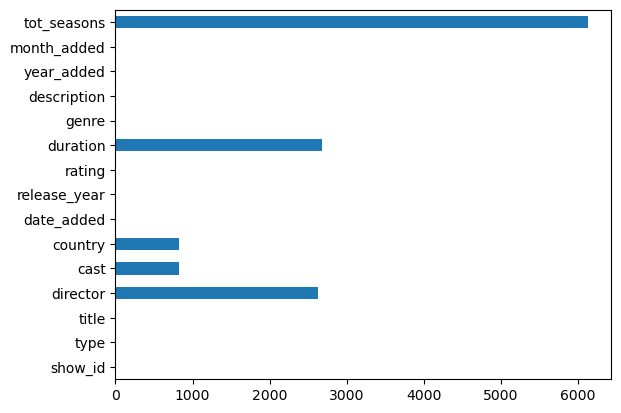

```python
df.isna().sum().plot(kind='barh')
plt.show()
```

~ 30%,70%,30% of duration,tot_seasons and director values are missing

1. Non-Graphical Analysis: Value counts and unique attributes (10 Points)

```python
cat_var=df.select_dtypes(include='object').columns.tolist()
num_var=df.select_dtypes(exclude='object').columns.tolist()

print(f"Categotical variables : {cat_var}, Count:{len(cat_var)}\n")
print(f"Numerical variables : {num_var}, Count: {len(num_var)}")
```

```
Categotical variables : ['show_id', 'type', 'title', 'director', 'cast', 'country', 'rating', 'genre', 'description'], Count:9

Numerical variables : ['date_added', 'release_year', 'duration', 'year_added', 'month_added', 'tot_seasons'], Count: 6
```

```python
for col in df.columns:
    print(f"unique {col} values = {df[col].nunique()}")
```

```
unique show_id values = 8807
unique type values = 2
unique title values = 8807
unique director values = 4528
unique cast values = 7692
unique country values = 748
unique date_added values = 1714
unique release_year values = 74
unique rating values = 17
unique duration values = 205
unique genre values = 514
unique description values = 8775
unique year_added values = 14
unique month_added values = 12
unique tot_seasons values = 15
```

```python
for col in df.columns:
    if df[col].nunique()<20:
        print(col,'\n',df[col].value_counts(),'\n','-'*50)
```

```
type
 Movie      6131
TV Show    2676
Name: type, dtype: int64
 --------------------------------------------------
rating
 TV-MA       3207
TV-14       2160
TV-PG        863
R            799
PG-13        490
TV-Y7        334
TV-Y         307
PG           287
TV-G         220
NR            80
G             41
TV-Y7-FV       6
NC-17          3
UR             3
74 min         1
84 min         1
66 min         1
Name: rating, dtype: int64
 --------------------------------------------------
year_added
 2019.0    2016
2020.0    1879
2018.0    1649
2021.0    1498
2017.0    1188
2016.0     429
2015.0      82
2014.0      24
2011.0      13
2013.0      11
2012.0       3
2009.0       2
2008.0       2
2010.0       1
```

[output cut: 20 more lines]

```
3.0      199
4.0       95
5.0       65
6.0       33
7.0       23
8.0       17
9.0        9
10.0       7
13.0       3
15.0       2
12.0       2
11.0       2
17.0       1
Name: tot_seasons, dtype: int64
 --------------------------------------------------
```

1. Visual Analysis - Univariate, Bivariate after pre-processing of the data
- Note: Pre-processing involves unnesting of the data in columns like Actor, Director, country
- 4.1 For continuous variable(s): Distplot, countplot, histogram for univariate analysis (10 Points)
- 4.2 For categorical variable(s): Boxplot (10 Points)
- 4.3 For correlation: Heatmaps, Pairplots (10 Points)

```python
genre_df=df[['type', 'title', 'director', 'cast', 'country', 'date_added','release_year', 'rating', 'duration', 'genre'
,'year_added', 'month_added', 'tot_seasons']]
director_df=genre_df.copy()
actor_df=genre_df.copy()
mixed_df=genre_df.copy()
```

```python
genre_df['genre']=genre_df['genre'].str.split(',')
director_df['director']=director_df['director'].str.split(',')
actor_df['cast']=actor_df['cast'].str.split(',')
genre_df=genre_df.explode('genre')
director_df=director_df.explode('director')
actor_df=actor_df.explode('cast')
```

```python
mixed_df['genre']=mixed_df['genre'].str.split(',')
mixed_df['director']=mixed_df['director'].str.split(',')
mixed_df['cast']=mixed_df['cast'].str.split(',')
mixed_df=mixed_df.explode('genre')
mixed_df=mixed_df.explode('director')
mixed_df=mixed_df.explode('cast')
```

```python
print(df.shape,genre_df.shape,director_df.shape,actor_df.shape,mixed_df.shape)
```

```
(8807, 15) (19323, 13) (9612, 13) (64951, 13) (161216, 13)
```

Univariate Analysis for continuous variables

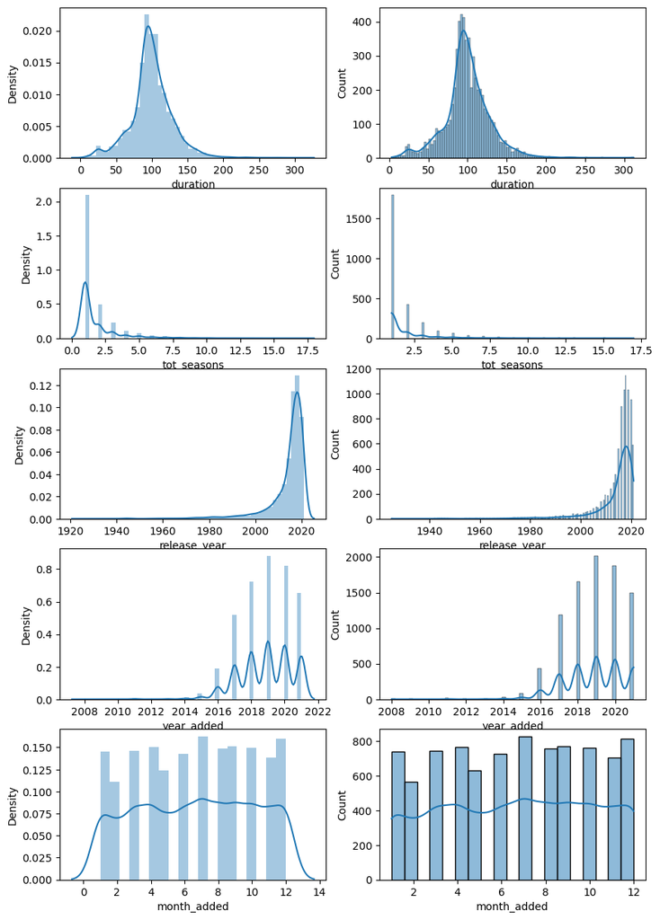

```python
#Univariate Analysis for continuous variables
cont_var=['duration','tot_seasons','release_year','year_added','month_added']
plt.figure(figsize=(10,15))
for i in range(1,len(cont_var)+1):
    plt.subplot(5,2,2*i-1)
    sns.distplot(df[cont_var[i-1]],kde=True)
    plt.subplot(5,2,2*i)
    sns.histplot(df[cont_var[i-1]],kde=True)
plt.show()
```

Distribution , univariate and bivariate analysis

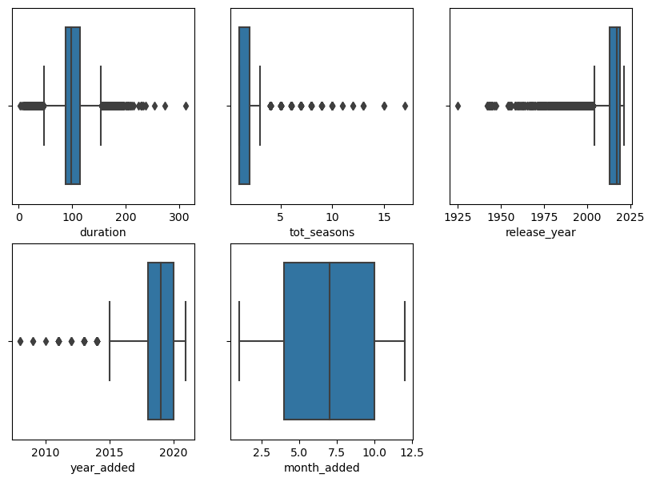

```python
plt.figure(figsize=(10,7))
for i in range(len(cont_var)):
    plt.subplot(2,3,i+1)
    sns.boxplot(x=cont_var[i], data=df)
```

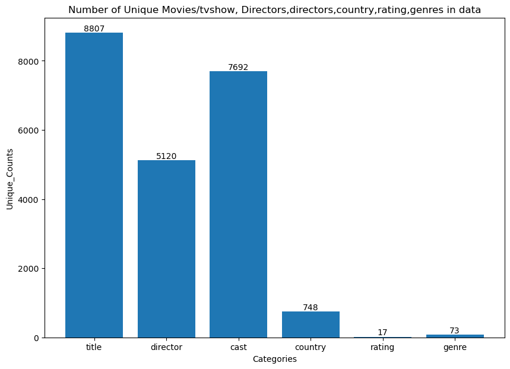

```python
cat_var=['title','director', 'cast', 'country', 'rating', 'genre']
counts = [df['title'].nunique(),director_df['director'].nunique(),director_df['cast'].nunique(),
          df['country'].nunique(),df['rating'].nunique(),genre_df['genre'].nunique()]
plt.figure(figsize=(10,7))
plt.bar(cat_var, counts)
plt.xlabel('Categories')
plt.ylabel('Unique_Counts')
plt.title('Number of Unique Movies/tvshow, Directors,directors,country,rating,genres in data')

for i, count in enumerate(counts):
    plt.text(i, count, str(count), ha='center', va='bottom')

plt.show()
```

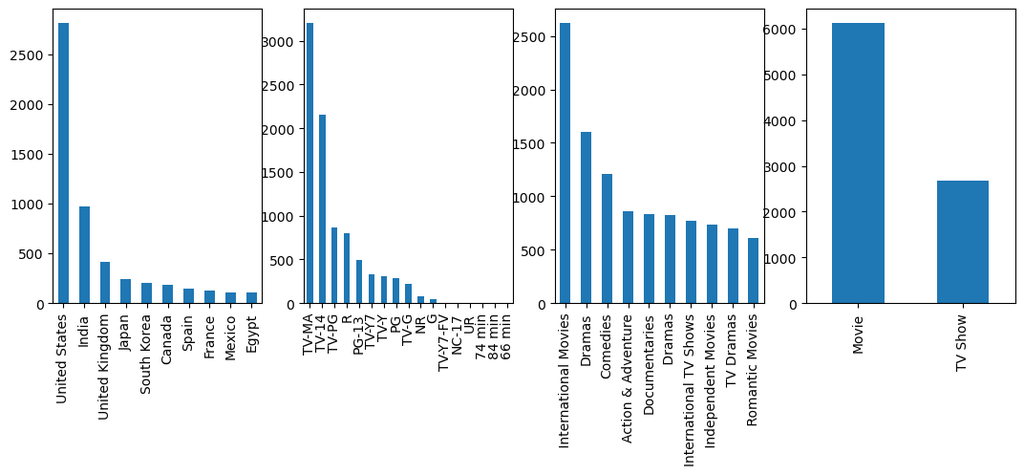

```python
plt.figure(figsize=(13,4))
plt.subplot(1,4,1)
df['country'].value_counts()[:10].plot(kind='bar')
plt.subplot(1,4,2)
df['rating'].value_counts().plot(kind='bar')
plt.subplot(1,4,3)
genre_df['genre'].value_counts()[:10].plot(kind='bar')
plt.subplot(1,4,4)
df['type'].value_counts().plot(kind='bar')
plt.show()
```

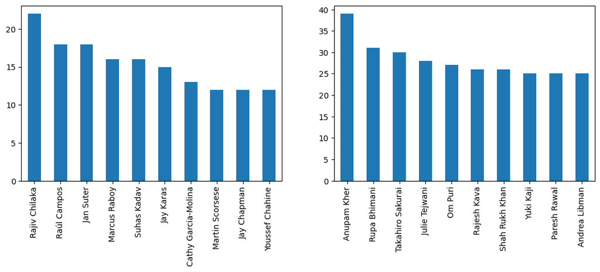

```python
plt.figure(figsize=(13,4))
plt.subplot(1,2,1)
director_df['director'].value_counts()[:10].plot(kind='bar')
plt.subplot(1,2,2)
actor_df['cast'].value_counts()[:10].plot(kind='bar')
plt.show()
```

The top 3 directors are Rajiv Chilaka,Raul Campos and Jan Suter, similarly we see the top 3 actors are Anupam Kher,rupa bimani,takahiro sakurai

Bivariate Analysis for continuous variables

```python
# How has the number of movies released per year changed over the last 20-30 years?
# Comparison of tv shows vs. movies.
# What is the best time to launch a TV show?
# Analysis of actors/directors of different types of shows/movies.
# Does Netflix has more focus on TV Shows than movies in recent years
# Understanding what content is available in different countries
```

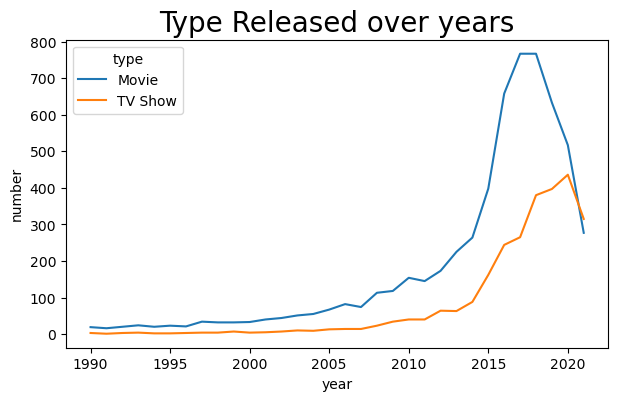

```python
# How has the number of movies released per year changed over the last 20-30 years?
temp=df[df['release_year']>=1990][["type","release_year"]].value_counts().reset_index()
temp.columns=["type","year","number"]
temp
plt.figure(figsize=(7,4))
sns.lineplot(data=temp,x="year",y="number",hue="type")
plt.title("Type Released over years",fontsize=20)
plt.show()
```

From 2014 onwards we see a spike in number of movies and tv-shows released when we see data from 1990 to 2020.

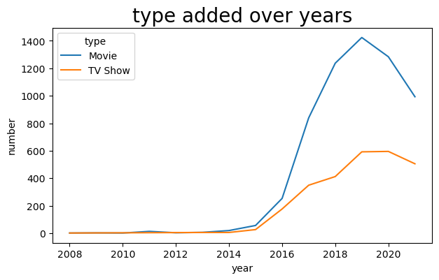

```python
temp=df[["type","year_added"]].value_counts().reset_index()
temp.columns=["type","year","number"]
temp
plt.figure(figsize=(7,4))
sns.lineplot(data=temp,x="year",y="number",hue="type")
plt.title("type added over years",fontsize=20)
plt.show()
```

We also see a spike in addition of movies /tv shows in netflix from 2016 onwards.

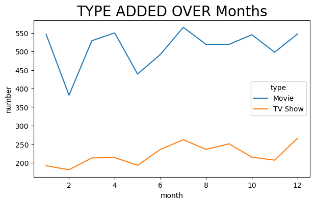

```python
# What is the best time to launch a TV show?
temp=df[["type","month_added"]].value_counts().reset_index()
temp.columns=["type","month","number"]
temp
plt.figure(figsize=(7,4))
sns.lineplot(data=temp,x="month",y="number",hue="type")
plt.title("TYPE ADDED OVER Months",fontsize=20)
plt.show()
```

The months more number of movies/tv show are released are 7th month.

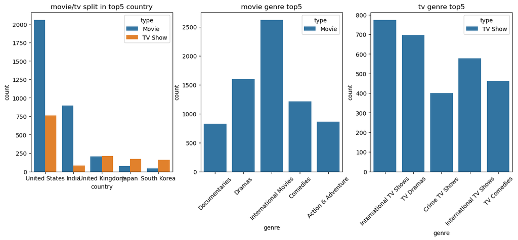

```python
# Comparison of tv shows vs. movies.
country_top5=df['country'].value_counts()[:5].index.to_list()
genre_top5=genre_df['genre'].value_counts()[:5].index.to_list()
moviegenre_top5=genre_df[genre_df['type']=='Movie']['genre'].value_counts()[:5].index.to_list()
tvgenre_top5=genre_df[genre_df['type']=='TV Show']['genre'].value_counts()[:5].index.to_list()
plt.figure(figsize=(15,5))
plt.subplot(1,3,1)
sns.countplot(df[df['country'].isin(country_top5)],x='country',hue='type')
plt.title('movie/tv split in top5 country')
plt.subplot(1,3,2)
sns.countplot(genre_df[genre_df['genre'].isin(moviegenre_top5)],x='genre',hue='type')
plt.xticks(rotation=45)
plt.title('movie genre top5')
plt.subplot(1,3,3)
sns.countplot(genre_df[genre_df['genre'].isin(tvgenre_top5)],x='genre',hue='type')
plt.xticks(rotation=45)
plt.title('tv genre top5')
plt.show()
```

```python
print(moviegenre_top5)
print(tvgenre_top5)
```

```
[' International Movies', 'Dramas', 'Comedies', 'Action & Adventure', 'Documentaries']
['International TV Shows', ' TV Dramas', ' International TV Shows', ' TV Comedies', 'Crime TV Shows']
```

We see in top 5 countries , movie count is lesser than tv show in UK,japan and South Korea.The top 5 genres in movies and tv show are the following [' International Movies', 'Dramas', 'Comedies', 'Action & Adventure','Documentaries'] and ['International TV Shows', ' TV Dramas', ' International TV Shows', ' TV Comedies', 'Crime TV Shows'] respectively.

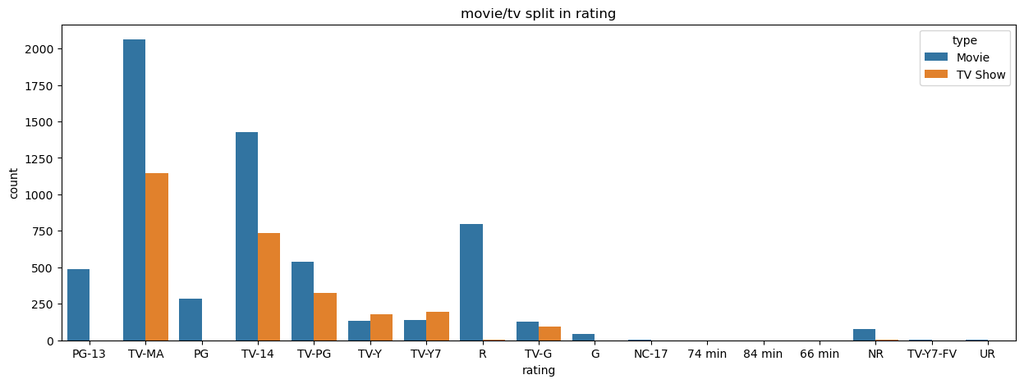

```python
plt.figure(figsize=(15,5))
sns.countplot(df,x='rating',hue='type')
plt.title('movie/tv split in rating')
plt.show()
```

Except TV-y and TV-7 all other ratings have movie count more than tv

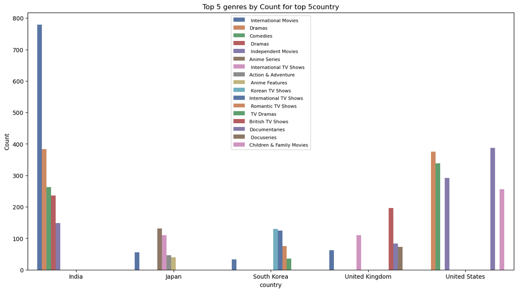

```python
plt.figure(figsize=(15,8))
grouped = genre_df[genre_df['country'].isin(country_top5)].groupby(['country', 'genre']).size().reset_index(name='Count')

# Sort the data within each country group by count in descending order
grouped = grouped.sort_values(['country', 'Count'], ascending=[True, False])


top_5_genres = grouped.groupby('country').head(5)


temp=sns.barplot(data=top_5_genres, x='country', y='Count', hue='genre',palette='deep')


plt.title('Top 5 genres by Count for top 5country')
plt.xlabel('country')
plt.ylabel('Count')
plt.legend(loc='upper center')
# Display the plot
plt.setp(temp.get_legend().get_texts(), fontsize='8')
# for legend title
plt.setp(temp.get_legend().get_title(), fontsize='10')
plt.show()
```

```python
df.columns
```

```
Index(['show_id', 'type', 'title', 'director', 'cast', 'country', 'date_added',
       'release_year', 'rating', 'duration', 'genre', 'description',
       'year_added', 'month_added', 'tot_seasons'],
      dtype='object')
```

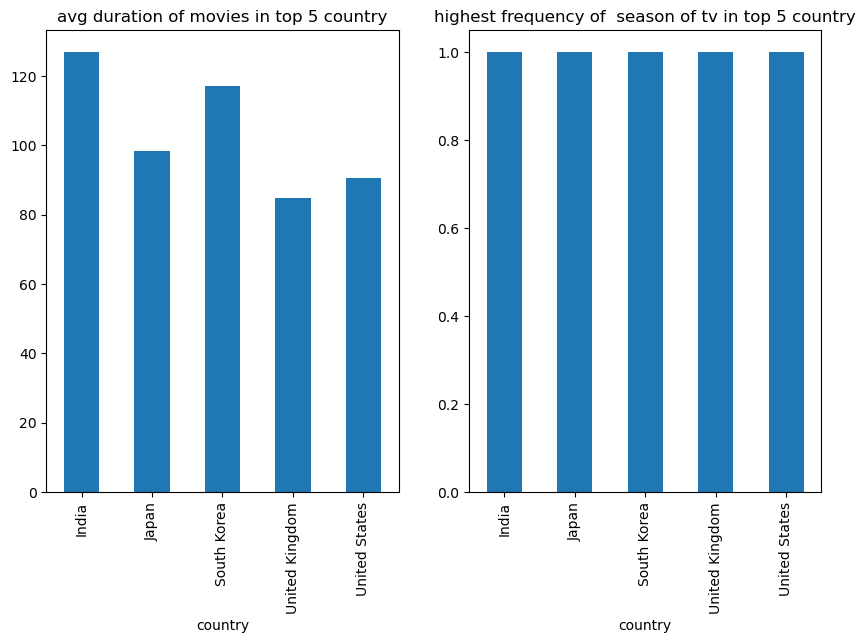

```python
plt.figure(figsize=(10,6))
plt.subplot(1,2,1)
df[df['country'].isin(country_top5)].groupby('country')['duration'].mean().plot(kind='bar')
plt.title('avg duration of movies in top 5 country')
plt.subplot(1,2,2)
df[df['country'].isin(country_top5)].groupby('country')['tot_seasons'].agg(pd.Series.mode).plot(kind='bar')
plt.title('highest frequency of  season of tv in top 5 country')
plt.show()
```

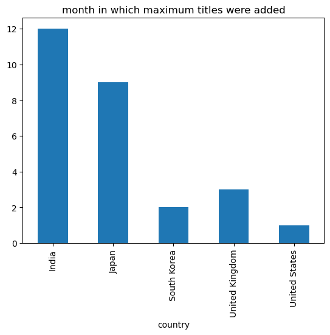

```python
df[df['country'].isin(country_top5)].groupby('country')['month_added'].agg(pd.Series.mode).plot(kind='bar')
plt.title('month in which maximum titles were added')
plt.show()
```

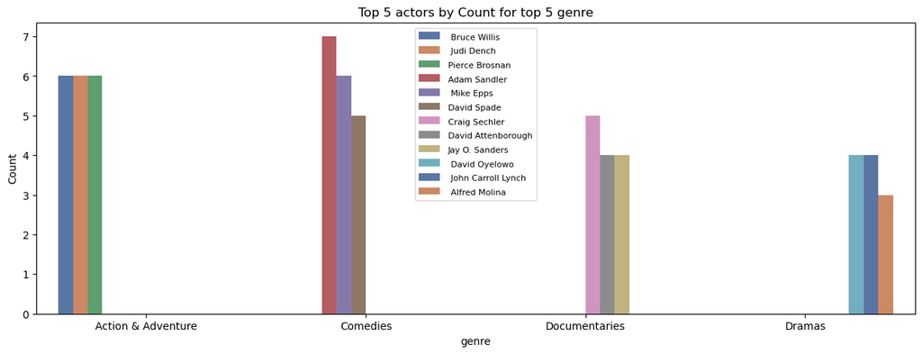

```python
# Analysis of actors/directors of different types of shows/movies.
plt.figure(figsize=(15,5))
grouped = actor_df[actor_df['genre'].isin(genre_top5)].groupby(['genre', 'cast']).size().reset_index(name='Count')

# Sort the data within each country group by count in descending order
grouped = grouped.sort_values(['genre', 'Count'], ascending=[True, False])


top_5_actors = grouped.groupby('genre').head(3)


temp=sns.barplot(data=top_5_actors, x='genre', y='Count',hue='cast',palette='deep')


plt.title('Top 5 actors by Count for top 5 genre')
plt.xlabel('genre')
plt.ylabel('Count')
plt.legend(loc='upper center')
# Display the plot
plt.setp(temp.get_legend().get_texts(), fontsize='8')
# for legend title
plt.setp(temp.get_legend().get_title(), fontsize='10')
plt.show()
```

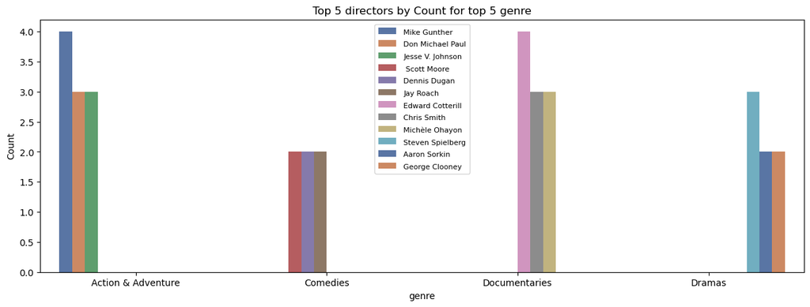

```python
# Analysis of actors/directors of different types of shows/movies.
plt.figure(figsize=(15,5))
grouped = director_df[director_df['genre'].isin(genre_top5)].groupby(['genre', 'director']).size().reset_index(name='Count')

# Sort the data within each country group by count in descending order
grouped = grouped.sort_values(['genre', 'Count'], ascending=[True, False])


top_5_directors = grouped.groupby('genre').head(3)


temp=sns.barplot(data=top_5_directors, x='genre', y='Count',hue='director',palette='deep')


plt.title('Top 5 directors by Count for top 5 genre')
plt.xlabel('genre')
plt.ylabel('Count')
plt.legend(loc='upper center')
# Display the plot
plt.setp(temp.get_legend().get_texts(), fontsize='8')
# for legend title
plt.setp(temp.get_legend().get_title(), fontsize='10')
plt.show()
```

```python
df.columns
```

```
Index(['show_id', 'type', 'title', 'director', 'cast', 'country', 'date_added',
       'release_year', 'rating', 'duration', 'genre', 'description',
       'year_added', 'month_added', 'tot_seasons'],
      dtype='object')
```

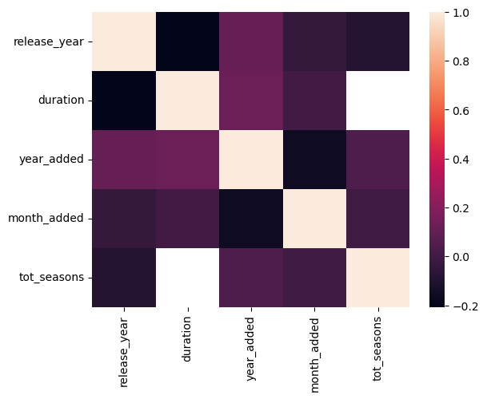

```python
sns.heatmap(df.corr())
```